# Oxford Happiness Questionnaire

coop711

2023-04-19

옥스포드 행복 설문지 실험결과를 분석한다. 이 실험에는 두 가지 목적이 있다. 첫째는 있는 그대로 옥스포드 행복 설문지로 측정하는 여러분의 행복 수준은 어느 정도인지, 둘째는 영문판으로 응답할 때와 국문판으로 응답할 때 어떤 차이가 있는지, 특히 응답에 소요되는 시간을 측정해 보았다.

## Red, Black을 잘못 표시한 사람들

랜덤화출석부에 있는 Red, Black 과 실제 구글설문에 올린 Red, Black 이 다른 사람들이 있어서 파악해 보았습니다. 랜덤화 효과는 여기서도 작동하고 있는 걸 알 수 있습니다. Red를 Black 이라고 한 사람의 수효(12명)과 Black을 Red 라고 한 사람의 수효(7명)이 비슷합니다 group 을 잘못 기억하고 있는 사람들의 수효조차 Red, Black 에 비슷하게 나뉘었습니다. 굳이 학번까지 올린 이유는 그 다음 구글예습퀴즈부터라도 제대로 올려주길 바라서입니다.

| 학번 | 랜덤화출석부 | 옥스포드행복설문지 |
| --- | --- | --- |
| 20183716 | Red | Black |
| 20191501 | Red | Black |
| 20192914 | Black | Red |
| 20194108 | Red | Black |
| 20198069 | Red | Black |
| 20202920 | Black | Red |
| 20213010 | Black | Red |
| 20213929 | Red | Black |
| 20215114 | Red | Black |
| 20221526 | Red | Black |
| 20221531 | Black | Red |
| 20221607 | Red | Black |
| 20222231 | Black | Red |
| 20222413 | Red | Black |
| 20222535 | Red | Black |
| 20222732 | Black | Red |
| 20222742 | Red | Black |
| 20232619 | Black | Red |
| 20233832 | Red | Black |

|  | Red(옥스포드행복설문지) | Black(옥스포드행복설문지) |
| --- | --- | --- |
| **Red(랜덤화출석부)** | 449 | 12 |
| **Black(랜덤화출석부)** | 7 | 438 |

## 행복 점수 비교

국문 설문지와 영문 설문지의 행복점수를 비교한다. 행복점수 단계별로 비교했을 때나 기초통계로 비교했을 때나 국문 설문지로 작성한 그룹 (Red)의 행복점수가 높게 나온다. 이는 통계적으로 매우 매우 유의한 수준이다.

### `summary()`

- **국문**:

  | Min. | 1st Qu. | Median | Mean | 3rd Qu. | Max. |
  | --- | --- | --- | --- | --- | --- |
  | 1.966 | 3.517 | 4 | 4.067 | 4.655 | 5.69 |

- **영문**:

  | Min. | 1st Qu. | Median | Mean | 3rd Qu. | Max. |
  | --- | --- | --- | --- | --- | --- |
  | 2.276 | 3.483 | 3.793 | 3.895 | 4.241 | 5.621 |

### `table()`

|  | 행복하지 않다 | 다소 행복하지 않다 | 그저 그렇다 | 꽤 행복하다 | 매우 행복하다 | 계 |
| --- | --- | --- | --- | --- | --- | --- |
| **국문** | 1 | 20 | 202 | 183 | 50 | 456 |
| **영문** | 0 | 14 | 261 | 147 | 28 | 450 |
| **계** | 1 | 34 | 463 | 330 | 78 | 906 |

Pearson’s Chi-squared test with simulated p-value (based on 2000 replicates): `.`

| Test statistic | df | P value |
| --- | --- | --- |
| 18.68 | NA | 0.0009995 * * * |

### 백분율(%)

| 행복하지 않다 | 다소 행복하지 않다 | 그저 그렇다 | 꽤 행복하다 | 매우 행복하다 | 계 |
| --- | --- | --- | --- | --- | --- |
| 0.1 | 3.8 | 51.1 | 36.4 | 8.6 | 100.0 |

### `geom_boxplot()`

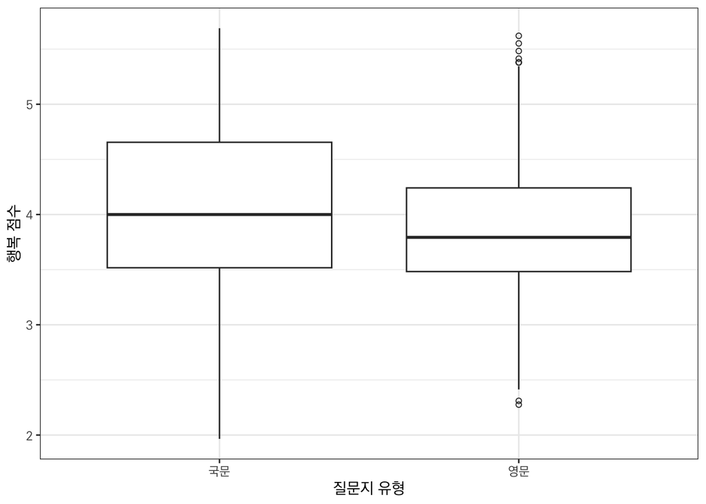

### `t.test()` on means

Welch Two Sample t-test: `Scores` by `Group`

| Test statistic | df | P value | Alternative hypothesis | mean in group 국문 | mean in group 영문 |
| --- | --- | --- | --- | --- | --- |
| 3.921 | 870.8 | 4.753e-05 * * * | greater | 4.067 | 3.895 |

## 소요시간 비교

초 단위로 측정한 소요시간에서는 오전, 오후를 잘못 쓴다거나 시작 시간이 제출 시간보다 늦게 입력한 사람들이 있고, 과도하게 (한 시간) 이상 소요된 것으로 나오는 사람들이 있어서 일일이 찾아서 수정하였고, 한 시간 이상은 사실상 설문지를 작성하다가 다른 일을 하고 다시 돌아와 마치는 과정을 의미하는 것으로 판단하여 NA 로 처리하였다. 소요 시간에 있어서도 국문과 영문에는 통계적으로 매우 유의한 수준의 차이가 관찰되었다.

평균적으로 89.2초, 즉 1분 29초정도 국문 질문지에 더 빨리 응답한다. 소요시간의 중위값을 비교해 보면 29.5 초, 약 0분 30초 만큼 국문 질문지에 더 빨리 응답하지만 통계적으로 유의한 수준은 아니다.

### `summary()`

- **국문**:

  | Min. | 1st Qu. | Median | Mean | 3rd Qu. | Max. | NA’s |
  | --- | --- | --- | --- | --- | --- | --- |
  | 1 | 130 | 184.5 | 286.4 | 257.8 | 3383 | 32 |

- **영문**:

  | Min. | 1st Qu. | Median | Mean | 3rd Qu. | Max. | NA’s |
  | --- | --- | --- | --- | --- | --- | --- |
  | 10 | 114.5 | 214 | 375.5 | 422.5 | 3436 | 39 |

### `geom_boxplot()`

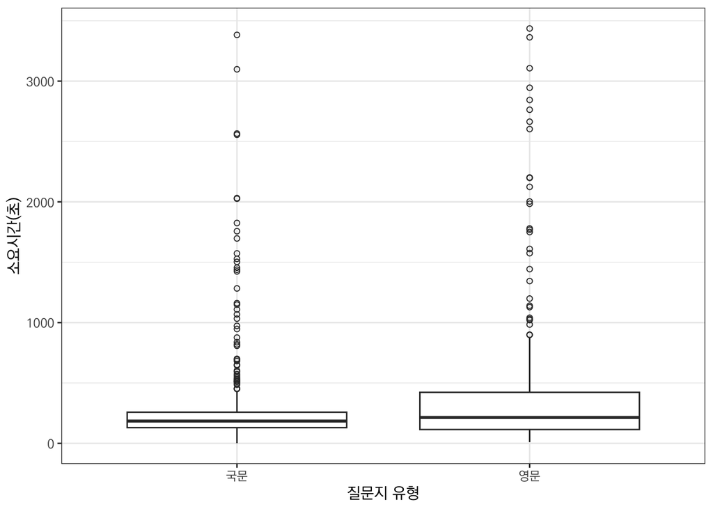

### `t.test()` on means

Welch Two Sample t-test: `as.numeric(Duration)` by `Group`

| Test statistic | df | P value | Alternative hypothesis | mean in group 국문 | mean in group 영문 |
| --- | --- | --- | --- | --- | --- |
| -2.864 | 771.5 | 0.004291 * * | two.sided | 286.4 | 375.5 |

### 일 단위 마감 시간으로부터 제출 시간의 분포

일 단위

|  | [0,1] | (1,2] | (2,3] | (3,4] | (4,5] | (5,6] | (6,7] | (7,8] | (8,9] | (9,10] | (10,11] | (11,12] | (12,13] | (13,14] |
| --- | --- | --- | --- | --- | --- | --- | --- | --- | --- | --- | --- | --- | --- | --- |
| **Red** | 207 | 56 | 20 | 14 | 16 | 9 | 14 | 29 | 15 | 13 | 20 | 18 | 12 | 18 |
| **Black** | 201 | 51 | 31 | 11 | 15 | 10 | 16 | 28 | 17 | 20 | 10 | 14 | 7 | 14 |

Pearson’s Chi-squared test: `.`

| Test statistic | df | P value |
| --- | --- | --- |
| 10.27 | 13 | 0.6717 |

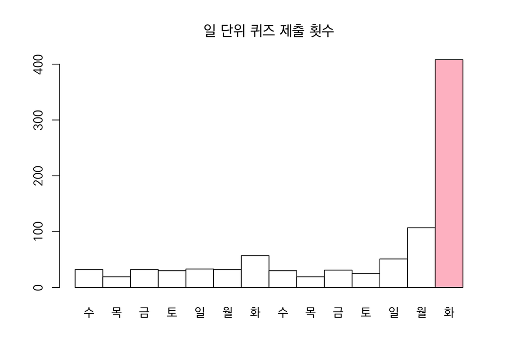